# E18 Mice Heart Cell scRNA Seq Analysis

Ling Min Hao

25 October, 2021

```r
# Load the libraries
library(Seurat)
library(tidyverse)
library(ggpubr)
library(Matrix)
library(cowplot)
library(enrichR)
```

## Introduction

```r
#Preparing 1k Heart Cells from an E18 mouse dataset
## Download the dataset and import into Seurat
heart.data <- Read10X(data.dir = "filtered_feature_bc_matrix/")
heart <- CreateSeuratObject(counts = heart.data)
```

**Cardiomyocyte** is a cell type responsible to generate contractile force in the intact heart. Here we perform single-cell RNA-seq on an **E18 Mice Heart Cell** dataset, with the advantage to attribute findings specifically to the cardiomyocytes rather than interactions with other cell types.

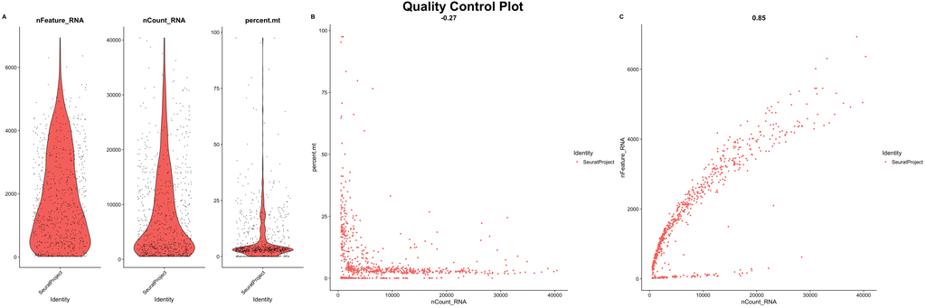

```r
## Perform downstream QC steps to filter the data

# nCount_RNA is the number of UMI counts in a cell
# nFeature_RNA is the number of different genes that had any reads (detected)
# percent.mt is the percent mitochondrial reads

# Add percent.mt content
heart$percent.mt <- PercentageFeatureSet(heart, pattern = "^mt-")

# QC plots
violin_QC <- VlnPlot(heart, features = c("nFeature_RNA", "nCount_RNA",
                            "percent.mt"), ncol = 3)
feature_QC1 <- FeatureScatter(heart, feature1 = "nCount_RNA",
                              feature2 = "percent.mt")
feature_QC2 <- FeatureScatter(heart, feature1 = "nCount_RNA", feature2 = "nFeature_RNA")

qc_final <- ggarrange(violin_QC,feature_QC1,feature_QC2, ncol = 3, labels = "AUTO")
annotate_figure(qc_final, top = text_grob("Quality Control Plot", face = "bold", size = 30))
```

```r
# Subset to remove low quality cell
heart <- subset(heart, subset = nCount_RNA < 20000 &
                 nFeature_RNA < 4000 & percent.mt < 15)
```

The E18 Mice Heart Cell dataset is first filtered way from poor quality data after interpreting the QC plot above.

## Results

### 1. Cell Type Identification

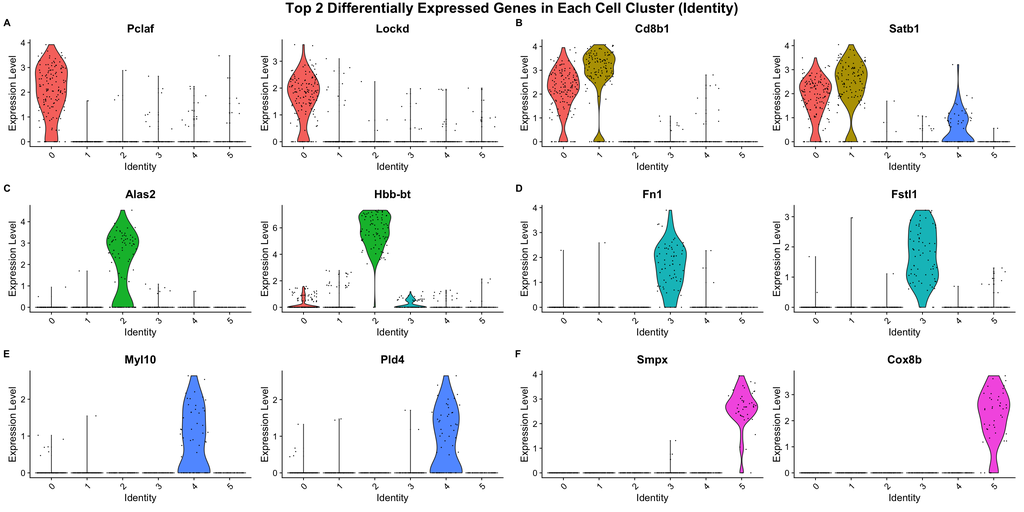

```r
### Do the steps necessary for getting a UMAP of the data and clusters

## Normalize and Scaling
heart <- heart %>%
  NormalizeData() %>%
  FindVariableFeatures() %>%
  ScaleData()

## Principal Component Analysis (PCA)
heart <- RunPCA(heart)

# Select number of PCs using the below Elbow Plot
# ElbowPlot(heart, ndims = 50)

## Nearest neighbor graph, clustering, and embedding
# number of PCs = 30
heart <- heart %>%
  FindNeighbors(dims = 1:30) %>%
  FindClusters(resolution = 0.5) %>%
  RunUMAP(dims = 1:30)

## Assign and identify cell types to each cell in RenameIdents using panglaodb as
## reference
# Find markers for cluster
cluster_markers <- lapply(seq(0,5,1), function(label){
  FindMarkers(heart, ident.1 = label, only.pos = TRUE, logfc.threshold = .5,
              min.pct = 0.25)
})

# Violin plot for top 2 cluster markers
violin_plots <- lapply(cluster_markers, function(cluster) {
  VlnPlot(heart, features = rownames(cluster %>%top_n(2, -log10(p_val))))
})
violin_final <- ggarrange(plotlist = violin_plots, ncol = 2, nrow = 3, labels = "AUTO")
annotate_figure(violin_final, top = text_grob("Top 2 Differentially Expressed Genes in Each Cell Cluster (Identity)", face = "bold", size = 20))
```

Using the manual cell type classification technique, we obtain the **top 2 genes overexpressed** associated with each cell cluster labeled with numbers. Using these overexpressed genes and [PanglaoDb](https://panglaodb.se/search.html) database, we can quickly identify the cell type of each cluster. As a result, we obtain the **cell type cluster map** as shown below.

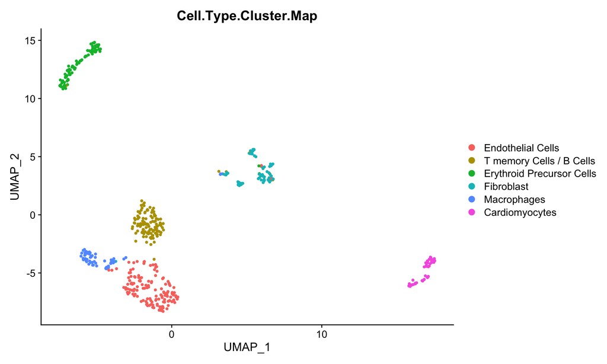

```r
# Renaming cell cluster using cell type
heart <- heart %>%
  RenameIdents(c(
  "0" = "Endothelial Cells",
  "1" = "T memory Cells / B Cells",
  "2" = "Erythroid Precursor Cells",
  "3" = "Fibroblast",
  "4" = "Macrophages",
  "5" = "Cardiomyocytes"
  ))

heart$Cell.Type.Cluster.Map <- Idents(heart)
Idents(heart) <- heart$seurat_clusters

# Dim plot of UMAP
DimPlot(heart, group.by = "Cell.Type.Cluster.Map")
```

### 2. Cluster Marker Analysis and Pathway Analysis

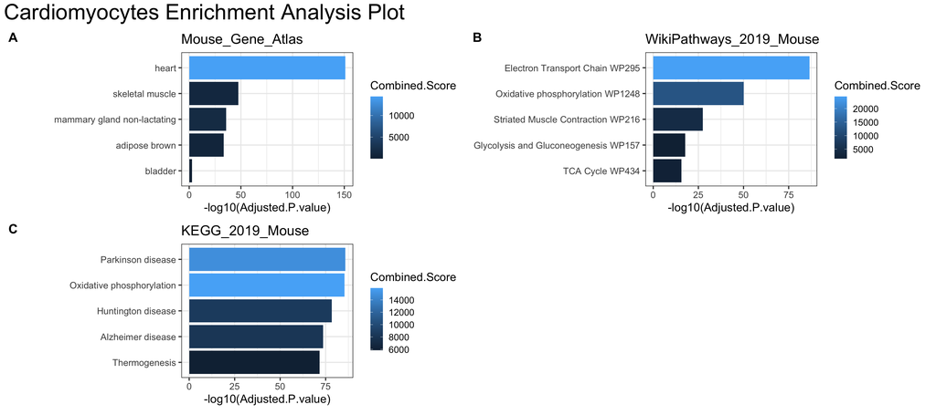

```r
### Cluster 5 (cardiomyocytes) Analysis
## Find all markers for all clusters
heart.markers <- FindAllMarkers(heart,
                               only.pos = TRUE,
                               min.pct = 0.25,
                               logfc.threshold = 0.5)
sig_markers <- heart.markers %>%
  filter(p_val_adj < .05)

## Select database to interpret
to_check <- c("Mouse_Gene_Atlas", "WikiPathways_2019_Mouse", "KEGG_2019_Mouse")

## Enrichment Analysis
# Pull the Cluster 5 genes as a vector
cluster5_genes <- sig_markers %>%
  filter(cluster == "5") %>%
  pull(gene)
# Run through enrichr
cluster5_eresList <- enrichr(cluster5_genes, databases = to_check)
# Plotting function for cluster enrichment results
plot_eres <- function(eres_name, eres_list, n = 5) {
  eres <- eres_list[[eres_name]]
  eres %>%
    top_n(n = n, wt = -log10(Adjusted.P.value)) %>%
    arrange(-log10(Adjusted.P.value)) %>%
    mutate(Term = factor(Term, levels = Term)) %>%
    ggplot(mapping = aes(x = Term, y = -log10(Adjusted.P.value), fill = Combined.Score)) +
    geom_bar(stat = "identity") +
    ggpubr::rotate() +
    theme_bw(base_size = 16) +
    rremove("ylab") +
    labs(title = eres_name)
}
# Get the top hits from each and plot them
plotList <- lapply(names(cluster5_eresList), plot_eres, eres_list = cluster5_eresList)
cowplot::plot_grid(plotlist = plotList, labels = "AUTO",
                   label_size = 18, align = "vh") +
  patchwork::plot_annotation(title = "Cardiomyocytes Enrichment Analysis Plot",
                             theme = theme(title = element_text(size = 25)))
```

## Interpretation of Results

Using **KEGG 2019 Mouse** database, we interestingly found that diseases like Parkinson’s Disease (Scorza et al. 2018) and Hummington’s Disease (Melkani 2016) might cause cardiomyocytes malfunction. Thus, the drugs that stimulate Electron Transport Chain and Oxidative Phosphorylation pathway would be needed for these patients as a preventive measure.

## References

Brown, David A, Justin B Perry, Mitchell E Allen, Hani N Sabbah, Brian L Stauffer, Saame Raza Shaikh, John GF Cleland, et al. 2017. “Mitochondrial Function as a Therapeutic Target in Heart Failure.” *Nature Reviews Cardiology* 14 (4): 238–50.

Melkani, Girish C. 2016. “Huntington’s Disease-Induced Cardiac Disorders Affect Multiple Cellular Pathways.” *Reactive Oxygen Species (Apex, NC)* 2 (5): 325.

Scorza, Fulvio A, Ana C Fiorini, Carla A Scorza, and Josef Finsterer. 2018. “Cardiac Abnormalities in Parkinson’s Disease and Parkinsonism.” *Journal of Clinical Neuroscience* 53: 1–5.